# Midterm 2 Review

PH142  
Spring 2019

### Navigating these slides

Welcome to the Midterm 2 Rpres. You can navigate these slides by

(1) **Arrows** by clicking the right and left arrows on your keyboard,  
(2) **Progress bar** by clicking on the progress bar located at the very bottom of your browser (it's a slim blue bar),  
(3) **Manual entry** by waiting a second, then typing in the slide number you wish to view within your URL address bar (change the last number in the URL to the slide number you wish to view.

If you cannot see the bottom of a slide try command-minus or control-minus.

### Exam logistics

Bring your (1) ID, (2) calculator, and (3) intelligent self to **your designated testing room** at 8:00am sharp on the 22nd of March.

### Note to Students

Please also consult lecture notes and your text. Many of you have been asking for sample problems. For understanding the material, textbook review exercises are great.

Use bCourses for all your statistical questions!

Good luck studying to all!

### Material

**PPDAC Application:** You will still be tested on your ability to intepret studies!  
**Chapter 9, 10:** Know when to apply your probability rules!  
**Chapter 11:** Continuous Distribution, Normal  
**Chapter 12:** Discrete Distributions, Binomial and Poisson  
**Chapter 13:** Sampling Distribution, the distribution of your sample statistics  
**Chapter 14, 15**: Hypothesis testing (CI's and z-test)

### PPDAC Applications

The following PPDAC application slides are difficult to read on this Rpres. To study this topic, click on the following link to Google slides.

[Click here!](https://docs.google.com/presentation/d/1bND-Wkc4Cm6fxZWyb2cwpxj_mGoQSfpEGmcThvTb4CY/edit?usp=sharing)

### Bias

##### Bias

When the expected value based on a sample differs from the true underlying parameter value.

**Take Home Questions:**

- What does it mean for a statistic to be unbiased?
- Can a parameter be unbiased?
- What does unbiased-ness have to do with the sampling distribution? (See Chapter 13 slides.)

### Probability

Chapter 9 and 10 are dense with formulas. Since you will most likely be putting these on your cheat sheet, your task is to be able to **read word problems** and **apply the appropriate rules** based on what the question is asking.

Look for patterns in language. Some words to look for are “given”, “and”, “or”, “both”, “neither”. *Can you name more? Read some of your homework problems and see which words relate to which probability.*

### Chapter 9

Random samples eliminate bias from the act of choosing a sample, **but they can still be wrong**

This is because of the variability that results when we choose at random.

If the variation when we take repeat samples from the same population is too great (really big), we can't trust the results of any one sample.

### Probablity

- The **probability** of any outcome of a random phenomenon is the proportion of times the outcome would occur in a very long series of repetitions.
- We call a phenomenon **random** if individual outcomes are uncertain but there is nonetheless a regular distribution of outcomes in a large number of repetitions.

### Sample Space

- A **sample space** \( S \) of a random phenomenon is a set of all possible outcomes.
- An **event** on sample space \( S \) is an outcome (or a set of outcomes) of a random phenomenon. That is, an event is a subset of the sample space.

### Probability Model

A **probability model** is a math description of a random phenomenon consisting of two parts: a sample space \( S \) and a way of assigning probabilities to events.

*Remember doing this in your homework?*

### Probability Rules

**Rule 1.** The probability P(A) of any event satisfies \( 0\leq P(A)\leq 1 \).  
**Rule 2.** If S is the sample space in a probability model, then P (S) = 1.  
**Rule 3.** Two events A and B are disjoint (mutually exclusive) if they have no outcomes in common and so can never occur together.

If A and B are disjoint, \( P(A U B) = P(A) + P(B) \). This is the addition rule for disjoint events.

**Rule 4.** The Complement Rule. For any event A,

\( P(A^C) = 1 - P (A) \)

where \( P(A^C) \) is the probability that A does not occur.

### Probability Rules

**Take Home Question:** Where does Rule 4 appear when we're using distributions?

**Rule 4**. The Complement Rule. For any event A,

\( P(A^C) = 1 - P (A) \)

where \( P(A^C) \) is the probability that A does not occur.

### Notation

- The **mean** of a density curve is \( \mu \)
- The **standard deviation** of a density curve as \( \sigma \)
- The **sample mean** is denoted as \( \bar{x} \)

### Discrete models

A probability model with a sample space made up of a list of individual outcomes is called **discrete**.

**Example**  
e.g., Birth type: S = {vaginal, cesarean}  
e.g., Daily soda consumption: S = {0, 1, 2, 3, 4+}

**Relate this back to what you know about discrete data.**

### Continuous models

The sample space is now an entire interval of numbers:  
S = {all numbers between 0 and 1}

**Example**  
e.g., Annual income: S = {0 to \( \infty \)}

**Relate this back to what you know about continuous data.**

### Density Curve

- A **density curve** describes/model the overall pattern of a distribution. (No real data perfectly match a density curve!)
- It has area exactly 1 underneath it.
- Only intervals of values have positive (non-zero) probabilities.

**Question:** Does the normal distribution have a density curve? Does the binomial?

### Sampling with Code

The `sample_n` function can be used in this way. The `iris` dataset is built into `R`!

```r
library(dplyr)
sample_2    <- sample_n(iris, size = 2)
sample_2
```

```
  Sepal.Length Sepal.Width Petal.Length Petal.Width   Species
1          6.7         3.3          5.7         2.5 virginica
2          6.9         3.1          5.4         2.1 virginica
```

### Sampling with Code

The `sample_n` function can be used in this way. The `iris` dataset is built into `R`!

```r
sample_6  <- sample_n(iris, size = 6)
sample_6
```

```
  Sepal.Length Sepal.Width Petal.Length Petal.Width    Species
1          6.5         3.0          5.2         2.0  virginica
2          5.8         2.7          4.1         1.0 versicolor
3          5.8         2.7          5.1         1.9  virginica
4          5.1         3.5          1.4         0.3     setosa
5          5.7         2.8          4.5         1.3 versicolor
6          5.6         2.5          3.9         1.1 versicolor
```

### Chapter 10

Now, we're *sliding* into Chapter 10 material.

### Dependence and Independence

Two events are independent if knowing that one event occurred does not change the probability that the other occurred

### Multiplication Rule for Independent Events

Two events A and B are independent if knowing that one occurs does not change the probability that the other occurs. If A and B are independent,

\( P(A \cap B) = P(A)\times P(B) \)

Conversely, if this condition is not satisfied, then events A and B are dependent.

### Conditional Probability

When P(A) > 0, the conditional probability of B, given A, is

\( P(B|A)=\frac{P(A\&B)}{P(A)} \)

### General addition rule for any two events

For any two events A and B, \( P(A \cup B) = P(A) + P(B) - P(A \cap B) \).

This formula simplifies to \( P(A \cup B) = P(A) + P(B) \) when A and B are **disjoint**.

### Example

**Hearing impairment in dalmatians** Congenital sensorineural deafness is the most common form of deafness in dogs and is often associated with congenital pigmentation deficiencies.

A study of hearing impairment in dogs examined over five thousand dalmatians for both hearing impairment and iris color. Being Impaired was defined as deafness in either one or both ears. Dogs with one or both irises blue (a trait due to low iris pigmentation) were labeled blue.

The study found that 28% of the dalmatians were hearing impaired, 11% were blue eyed, and 5% were hearing impaired and blue eyed.

### Example

**Hearing impairment in dalmatians** Congenital sensorineural deafness is the most common form of deafness in dogs and is often associated with congenital pigmentation deficiencies.

A study of hearing impairment in dogs examined over **5000** dalmatians for both hearing impairment and iris color. Being Impaired was defined as deafness in either one or both ears. Dogs with one or both irises blue (a trait due to low iris pigmentation) were labeled blue.

The study found that **28%** of the dalmatians were hearing impaired, **11%** were blue eyed, and **5%** were hearing impaired and blue eyed.

### Example

**Question** Write up information from the prompt in probability notation.

**Solution**  
\( P(I) = 0.28 \)  
\( P(B) = 0.11 \)  
\( P(B \cap I) = 0.05 \)

### Example

**Question** What is the probability of dalmatians being either blue eyed or hearing impaired?

**Solution**  
\( P(B \cup I) = P(B) + P(I) - P(B\cap I) = 0.11 + 0.28 - 0.05 = 0.34 \)

### Example

**Additional Questions for Home:**

- What is the probability of a dalmatian being unimpaired and brown-eyed dog if it is neither hearing impaired nor blue eyed?
- Are \( B \) and \( I \) independent? Or dependent?

*If this was difficult to answer, please refer to Sarah's Venn Diagram notes on bCourses.*

### General multiplication rule

\( P(A \cap B) = P(A)P(B|A) \). This is simply a rearrangement of the conditional probability formula.

This simplifies to \( P(A \cap B) = P(A) \times P(B) \) when A and B are independent events.

### Bayes' Theorem

\( P(A|B)=P(A) \) if independent. But if they aren't…

\[ P(A|B) =\frac{P(B|A)P(A)}{P(B|A)P(A) + P(B|A^c)P(A^c)} \]

\[ P(A|B) =\frac{P(A|B)P(B)}{P(B|A)P(A) + P(B|A^c)P(A^c)} \]

\[ P(A|B) =\frac{P(A \cap B)}{P(B|A)P(A) + P(B|A^c)P(A^c)} \]

### Absolute frequencies and tree diagrams

[figure not shown]

### Absolute frequencies and tree diagrams

[figure not shown]

### Absolute frequencies and tree diagrams

[figure not shown]

### Distributions

A common question has been **WHEN DO WE USE THESE DISTRIBUTIONS!?** Well, sometimes our data tell a story that we see over and over again.

We can think of distributions as things that model patterns in data. If we see data that looks approximately normal or follows a recipe for the Binomial or Poisson(*), then we should definitely consider using the appropriate distribution. When we use a distribution like one of the named three above, we can end up saying a lot about our data. We can say the mean, the variance/standard deviation, and calculate probabilities.

(*) See the following Chapter 11 and 12 notes for these recipes.

### Chapter 11: Normal Distribution

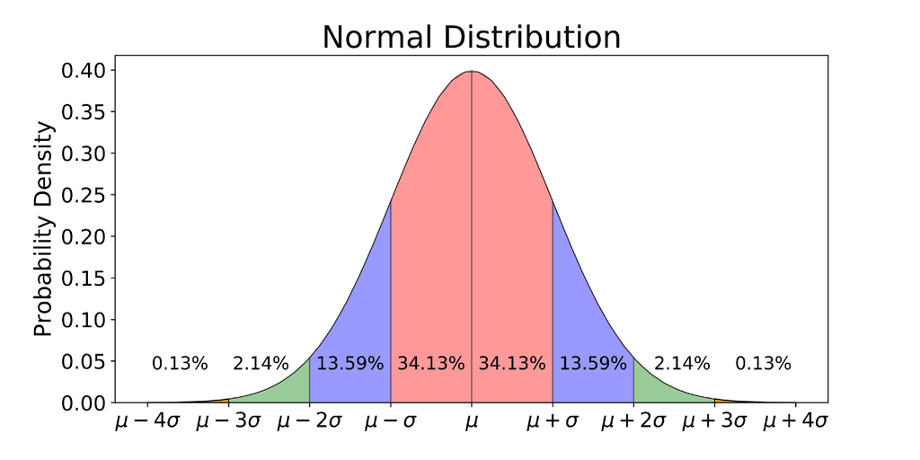

### Recipe for Normal

1. Goals: We want to find a probability for greater or less than or greater/equal, less/equal, but NEVER exactly equal to a single number
2. The data are said to be normal or are assumed to be normal in the prompt

### Question

What is the difference between normal and standard normal?

### Example

According to [basketball-reference.net](https://www.basketball-reference.com/leagues/NBA_stats.html), the mean height for NBA players is 6'7" = 79 inches. Suppose it is known that player height is normally distributed with a standard deviation of 4 inches. What is the probability of a ball player to be shorter than 6 feet?

### Example

The prompt information translates to:

```r
mu  <- 79
sd  <- 4
k   <- 6*12
```

We can calculate this probability one way (without tables!).

```r
pnorm(q=k, mean=mu, sd=sd)
```

```
[1] 0.04005916
```

All the `[ ]norm` functions are fair game!

### Chapter 12: Binomial and Poisson Distributions

Refer to your homework assignments for practice problems!

### Binomial

This is the formula for the Binomial distribution.

\[ P(X=k) = \Sigma_{k=0}^{n} \binom{n}{k}(p)^{k}(1-p)^{n-k} \]

Since you'll probably have this formula on your cheat sheet, what's more important is understanding what each of the pieces of the binomial distribution function.

As we said earlier, distributions are used to calculate means, variances, and probabilities of situations we see often! Think back to the Korean drama or pop song. They have well-known structures. So does the Binomial setting. Check if your data fit the Binomial setting.

### Binomial

Recipe for Binomial  
1. Goals: We want to find a probability, these are all fine: less than/equal/greater than/combo  
2. You have some fixed amount of trials  
3. Trials are independent  
4. The probability of success is the same for each trial  
5. **There may be more assumptions, look for these at home.**

### Normal Approximation for the Binomial Distribution

- If we have a binomial distribution that satisfies the below properties, we can approximate the distribution as a normal distribution instead
- This allows us to use all the awesome properties we know about normal distributions (very convenient!)

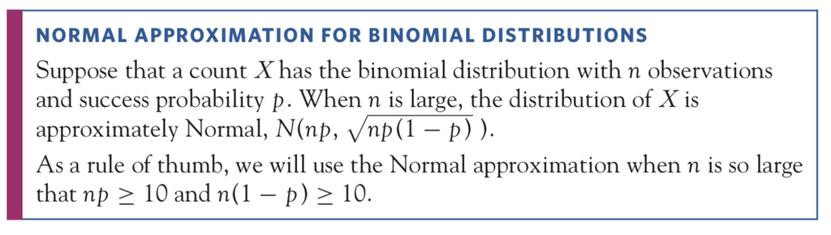

### Example

A shopper goes online Thursday mornings to attempt to purchase Supreme apparel and accessories. Due to the brand's popularity and limited supply, the shopper successfully purchases any item 1 in 10 times. What is the probability that the shopper will make 4 successful purchases after 10 independent purchase attempts? How about greater than 4?

### Example

The prompt information translates to:

```r
n_trials    <- 10
k_success   <- 4
probability <- 1/10
```

And we can calculate the first quantity “by hand” using the formula:

```r
choose(n_trials, k_success)*(probability)^k_success*(1-probability)^(n_trials-k_success)
```

```
[1] 0.01116026
```

### Example

The prompt information translates to:

```r
n_trials    <- 10
k_success   <- 4
probability <- 1/10
```

Or we can use a special function:

```r
dbinom(x=k_success, size=n_trials, prob=probability)
```

```
[1] 0.01116026
```

### Example

The second quantity (the probability of greater than 4) can be found by using the Complement Rule.

```r
1 - choose(n_trials, 4)*(probability)^(4)*(1-probability)^(n_trials-4) - choose(n_trials, 3)*(probability)^(3)*(1-probability)^(n_trials-3) - choose(n_trials, 2)*(probability)^(2)*(1-probability)^(n_trials-2) - choose(n_trials, 1)*(probability)^(1)*(1-probability)^(n_trials-1) - choose(n_trials, 0)*(probability)^(0)*(1-probability)^(n_trials-0)
```

```
[1] 0.001634937
```

### Example

Or using another cool function that calculate the sum of probabilities from 0 to k.

```r
1-pbinom(q=k_success, size=n_trials, prob=probability)
```

```
[1] 0.001634937
```

Or even more conveniently:

```r
pbinom(q=k_success, size=n_trials, prob=probability, lower.tail=FALSE)
```

```
[1] 0.001634937
```

All the `[ ]binom` functions are fair game!

### Poisson

This is the formula for the Poisson distribution.

\[ P(X=k) = e^{-\lambda}\frac{\lambda^k}{k!} \]

Recipe for Poisson  
1. Goals: We want to find a probability, these are all fine: greater/less/equal/combo  
2. Events occur independently. 3. The rate at which events occur is constant. The rate cannot be higher in some intervals and lower in other intervals. 3. **There are more assumptions, look for these at home.**

### Example

San Francisco is known for its fog. In fact, the fog's name is Karl! We expect a warm, sunny, Karl-free day in San Francisco about twice per month.

**Do this at home:** What is the probability that we see more than 5 days of sun in San Francisco in a month? How about exactly 10?

### Sampling Distributions

A sampling distribution is the distribution of estimates that we have for our parameter. In our case, we either make distributions of estimates for \( \mu \) or population proportion \( p \).

### Chapter 13

Here's a motivating figure from the text. After you're done looking over this section, reflect on this figure and see if you can understand it all.

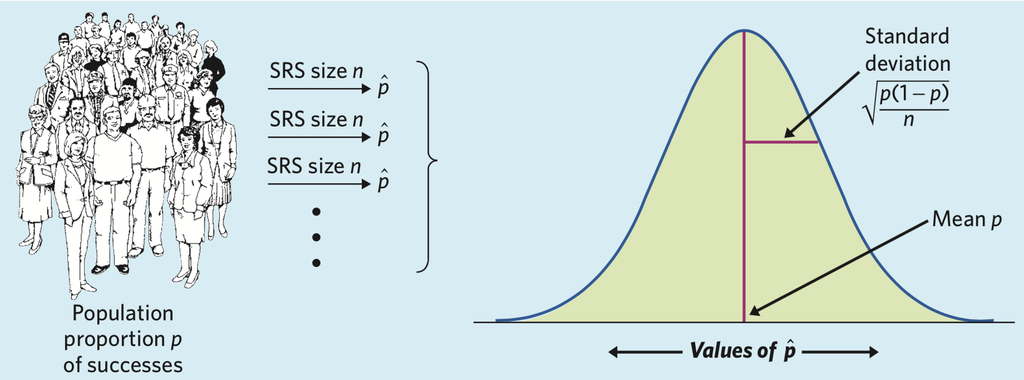

### Law of Large Numbers

##### Example

Let's take a look at some NBA data that was scraped off of basketball-reference.com. We'll read in the csv.

```r
western_conference <- read.csv("western_nba.csv")[,-1]
head(western_conference, 3)
```

```
             Player millions                  team
1     Stephen Curry 37.45715 Golden State Warriors
2 Russell Westbrook 35.65415 Oklahoma City Thunder
3        Chris Paul 35.65415       Houston Rockets
```

```r
mean(western_conference$millions)
```

```
[1] 6.500936
```

### Law of Large Numbers

In the following blocks, we're going to take 100 samples of size \( n=2, 5, 30 \). Ignore the code that you have you never learned. Focus on the output.

### Law of Large Numbers

###### Sampling with n=2

```r
sample_means_2 <- do.call(rbind, lapply(1:100, function(x) sample_n_salaries(2)))
sample_means_2 %>% summarize(sampling_mean=mean(mean_salary))
```

```
  sampling_mean
1      6.374358
```

### Law of Large Numbers

###### Sampling with n=5

```r
sample_means_5 <- do.call(rbind, lapply(1:100, function(x) sample_n_salaries(5)))
sample_means_5 %>% summarize(sampling_mean=mean(mean_salary))
```

```
  sampling_mean
1      6.019269
```

### Law of Large Numbers

###### Sampling with n=30

```r
sample_means_30 <- do.call(rbind, lapply(1:100, function(x) sample_n_salaries(30)))
sample_means_30 %>% summarize(sampling_mean=mean(mean_salary))
```

```
  sampling_mean
1      6.560197
```

### Central Limit Theorem

As \( n \) gets huge, our sampling distribution itself will look more and more like a normal distribution.

### Central Limit Theorem

##### Example

Recall the data from earlier.

```r
head(western_conference, 10)
```

```
              Player millions                   team
1      Stephen Curry 37.45715  Golden State Warriors
2  Russell Westbrook 35.65415  Oklahoma City Thunder
3         Chris Paul 35.65415        Houston Rockets
4       LeBron James 35.65415     Los Angeles Lakers
5        Paul George 30.56070  Oklahoma City Thunder
6        Mike Conley 30.52112      Memphis Grizzlies
7       James Harden 30.43185        Houston Rockets
8       Kevin Durant 30.00000  Golden State Warriors
9       Paul Millsap 29.73077         Denver Nuggets
10    Damian Lillard 27.97769 Portland Trail Blazers
```

### Central Limit Theorem

###### Exploring the Population (“The Underlying Distribution”)

This is the distribution of the population salaries.

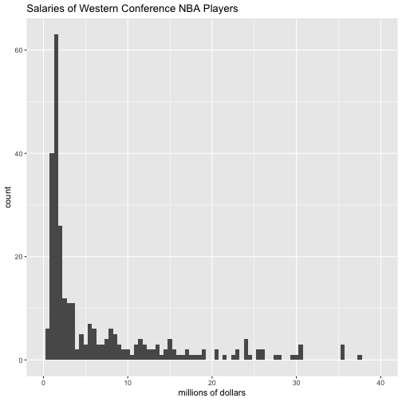

### Central Limit Theorem

###### Exploring the Population (“The Underlying Distribution”)

What is the mean parameter \( \mu \) of the population? We can calculate this by hand or by a function. Focus on the by hand calculation.

Here's the “by hand” calculation. The following functions may seem new to you, but think intuitively instead of code-wise. We have a data on all of the salaries, then we add all the salaries up, then divide by the number of salaries we have to get the average.

```r
vector_of_salaries <- western_conference$millions
sum(vector_of_salaries) / length(vector_of_salaries)
```

```
[1] 6.500936
```

### Central Limit Theorem

###### Exploring the Population (“The Underlying Distribution”)

What is the mean parameter \( \mu \) of the population? We can calculate this by hand or by a function. Focus on the by hand calculation.

Here's the `dplyr` solution.

```r
library(dplyr)
western_conference %>% summarize(mu=mean(vector_of_salaries))
```

```
        mu
1 6.500936
```

Let's see what our sample distribution looks like for several choices of \( n \).

### Central Limit Theorem

###### Sampling with n=2

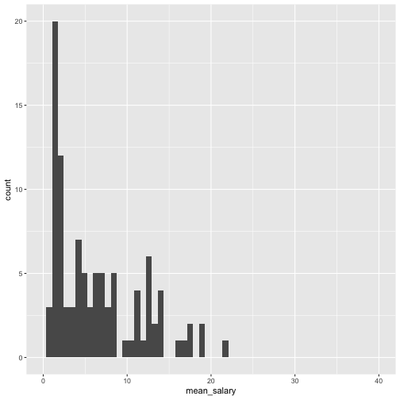

```r
ggplot(sample_means_2, aes(x=mean_salary)) +
  geom_histogram(binwidth=0.7) +
  scale_x_continuous(limits = c(0, 40))
```

### Central Limit Theorem

###### Sampling with n=5

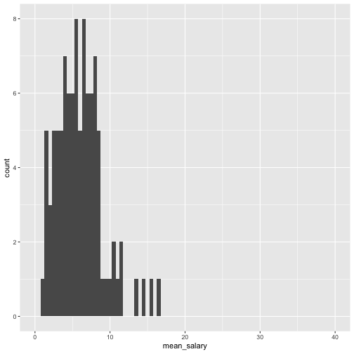

```r
ggplot(sample_means_5, aes(x=mean_salary)) +
  geom_histogram(binwidth=0.5) +
  scale_x_continuous(limits = c(0, 40))
```

### Central Limit Theorem

###### Sampling with n=30

Visually, the sample size of \( n=30 \) is the most symmetric.

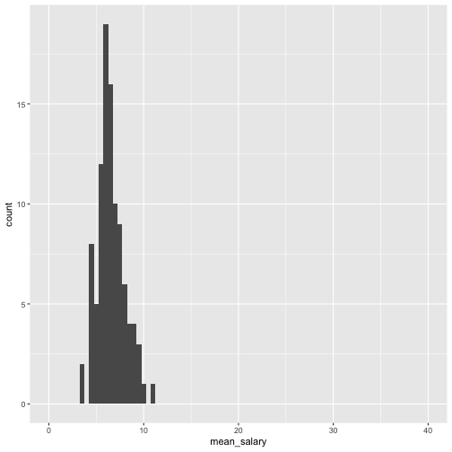

```r
ggplot(sample_means_30, aes(x=mean_salary)) +
  geom_histogram(binwidth=0.5) +
  scale_x_continuous(limits = c(0, 40))
```

As \( n \) gets larger, then we see the sampling distribution get less skewed and more like the normal curve.

### Sampling Distribution Means and Variances

Sampling distributions have means and variances that can be calculated as specified below!

```
             mean   variance
counts      x-bar sd/sqrt(n)
proportions     p (p(1-p))/n
```

**Question:** What is the relationship between variance and standard deviation?

**Question for Home:** What assumptions go along with sampling distributions and their normalities? Check the chapter.

### Chapter 14, 15

In these chapters, we introduce inference. **Inference** is the process of drawing conclusions about a population based on a sample. We will do this by testing hypotheses using confidence intervals and z-tests. Notice that the two methods to test hypotheses will bring about the same conclusions.

### Hypotheses

In inference, we're normally interested in hypotheses like:

\[ H_0: \mu = 5 \\ H_1: \mu \neq 5 \]

The first hypothesis is called your **null hypothesis** which specifies the status quo belief. The other hypothesis is called the **alternative hypothesis**.

A **confidence interval** can be used to test hypotheses. We also have covered using a **z-test**.

### Confidence Intervals

- A confidence interval can provide evidence for or against the null hypothesis.
- A confidence interval is of the form estimate \( \pm \) (margin of error).
- Margin of error is your critical value \( z_{\alpha/2} \) times (standard error).

\[ \bar{X} \pm z_{\alpha/2}\text{(SE)} \]

- For a 95% CI, \( z_{\alpha/2}=1.96 \). For a 90% CI, \( z_{\alpha/2}=1.64 \). In general, increasing your confidence level will make your intervals wider (and your critical value bigger).
- CI's are normally reported in this fashion \( (\text{LB}, \text{UB}) \)

### Confidence Intervals

The interpretation of a CI is very specific! Do **not** say that you are 95% sure that our true parameter is within our interval. Instead, this:

**Interpretation** Using a method that creates confidence intervals that capture the true parameter 95% of the time, we constructed the interval \( (\text{LB}, \text{UB}) \). This means that 95% of such intervals will contain our true parameter.

### Confidence Intervals

**Concluding based on a CI** How do we test hypotheses based on a CI? Recall our arbitrary hypotheses.

\[ H_0: \mu = 5 \\ H_1: \mu \neq 5 \]

### Z-testing

The general procedure for running a z-test (after identifying the parameter of interest and ensuring conditions are met) is:

1) State the null and alternative hypotheses  
2) Calculate the z test statistic  
3) Use the test statistic to find the p-value  
4) Generate a conclusion about your hypotheses using your p-value (reject vs. fail to reject the null)

Remember that we run a z-test when we know the true population standard deviation, \( \sigma \). You would be provided this value on the midterm.

### Z-test conditions

The conditions to run a z-test include:

1) The sample is a SRS (simple random sample)  
2) The data comes from a Normal distribution/population  
3) The true, population standard deviation \( \sigma \) is known

### Step 1: Hypotheses

Your hypotheses can be one-sided or two-sided.

- An example of a two-sided test is:

\[ H_0: \mu = 3, H_a: \mu \neq 3 \]

- Some examples of a one-sided test are:

\[ H_0: \mu = 3, H_a: \mu > 3 \]

or

\[ H_0: \mu = 3, H_a: \mu < 3 \]

Sometimes you are explicitly told what kind of a test to run. Other times, it is your responsibility to figure out which direction you test based on context from the word problem.

### Step 2: Z-value calculation

The formula for the z test statistic is:

\[ z = \frac{\bar{x} - \mu_0}{\sigma / \sqrt{n}} \]

where:

- \( \bar{x} \) is the sample mean (aka the statistic)
- \( \mu \) is the population mean that is part of the hypothesis (aka the parameter)
- \( \sigma \) is the population standard deviation
- n is the sample size

### Step 3: Finding the p-value

Once we have our z-value, we can find the p-value. To help find the p-value, sketch the standard Normal curve and mark on it the observed value of z. Depending on whether you are performing a **one-sided test** or a **two-sided**, this will determine in which direction you calculate the p-value/probability:

Here is a visual to illustrate the differences

#

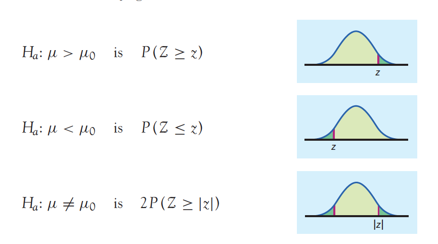

Use pnorm() functions to calculate your p-value. Remember we are working with a Standard normal.

### Step 4: Interpreting p-values

Once we have our p-values, we can relate these back to our hypotheses and come to a conclusion. Be careful interpreting p-values! The p-value represents the probability, assuming that \( H_0 \) is true, that the test statistic would take a value at least as extreme (in the direction of \( H_a \)) as that actually observed. Note that the p-value is **NOT** the probability that the null hypothesis is true.

The smaller the p-value, the stronger the evidence against \( H_0 \) provided by the data.

As a general rule of thumb, we:

- reject \( H_0 \) when p-value < \( \alpha \)
- fail to reject \( H_0 \) when p-value > \( \alpha \)

where \( \alpha \) is *typically* set to 0.05 (**unless otherwise stated in the problem**).

### Step 4: Interpreting p-values

Correct interpretations:

- If p < \( \alpha \): We found a p-value of p = [p-value]. This is less than our cut-off value of \( \alpha \) = [\( \alpha \)]. So we reject the null hypothesis that [null hypothesis] and have evidence to support the alternative hypothesis that [alternative hypothesis]
- If p \( \geq \alpha \): We found a p-value of p = [p-value]. This is greater than our cut-off value of \( \alpha \) = [\( \alpha \)]. so we fail to reject the null hypothesis that [null hypothesis] and do not have evidence to support the alternative hypothesis that [alternative hypothesis].

### Example (try on your own)

An environmentalist group collects a liter of water from each of 45 random locations along a stream. The mean amount of dissolved oxygen per liter is 4.62 mg. Suppose that we know that dissolved oxygen varies among locations according to a Normal distribution with \( \sigma \) = 0.92 mg. Is this strong evidence that the stream has a mean oxygen content of less than 5 mg per liter? Perform a hypothesis test by completing the following steps:

1) State your **null and alternate hypotheses** (hint: is it one-sided or two-sided?):

\[ H_0: \]

\[ H_a: \]

### Example (try on your own)

2) Calculate the **z-statistic**:

\[ z = \]

3) Find the **p-value**. Express this using probability notation, and write the proper pnorm() function to use.

**Probability notation**:

\[ p-value = \]

**Code**:

```r
pnorm(               )
```

4) Interpret your p-value.

### Type I and II Errors

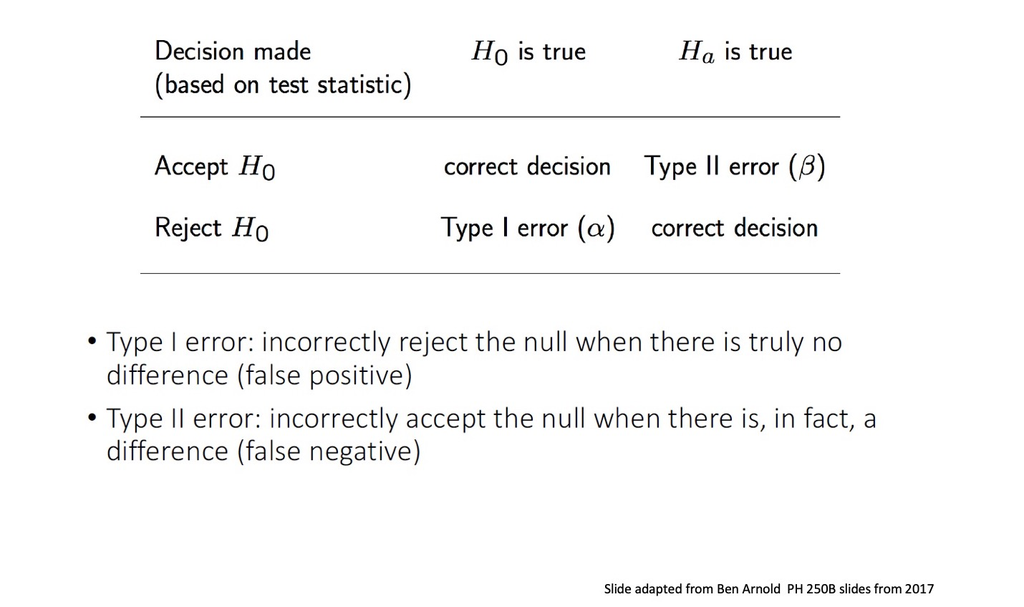

### Types I Error

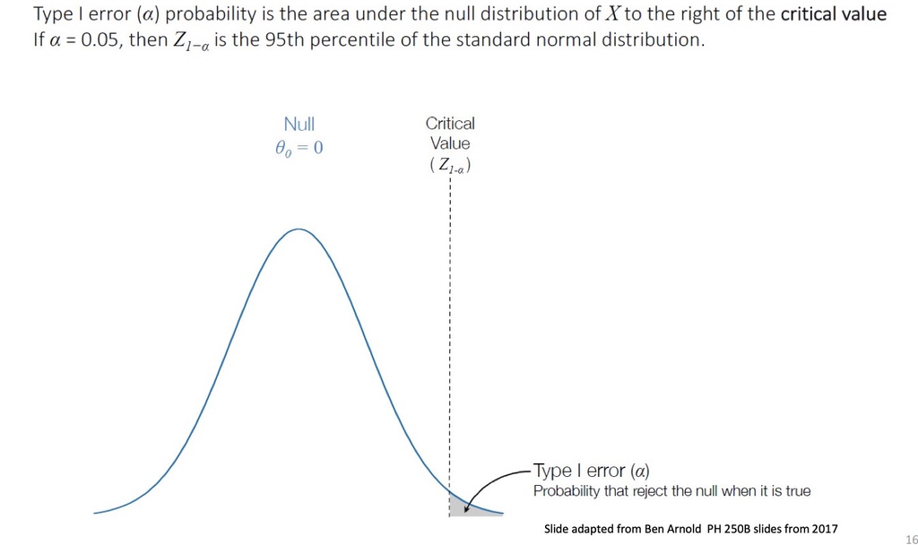

### Critical value

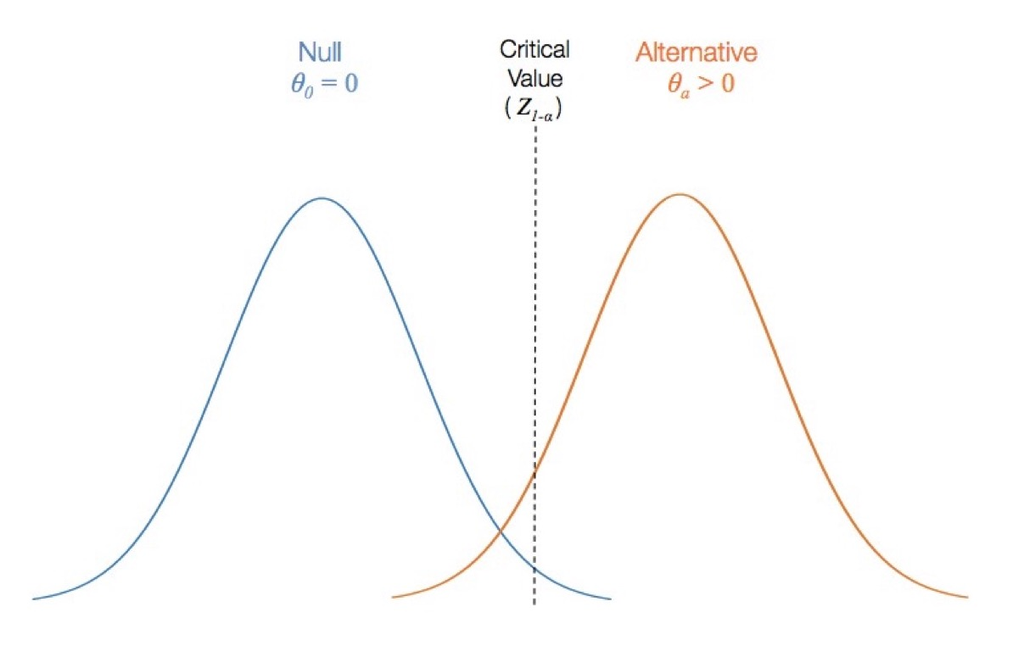

### Types II Error

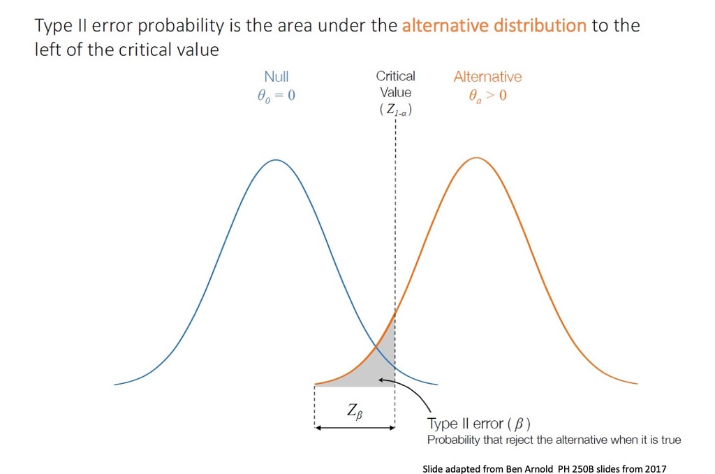

### Power

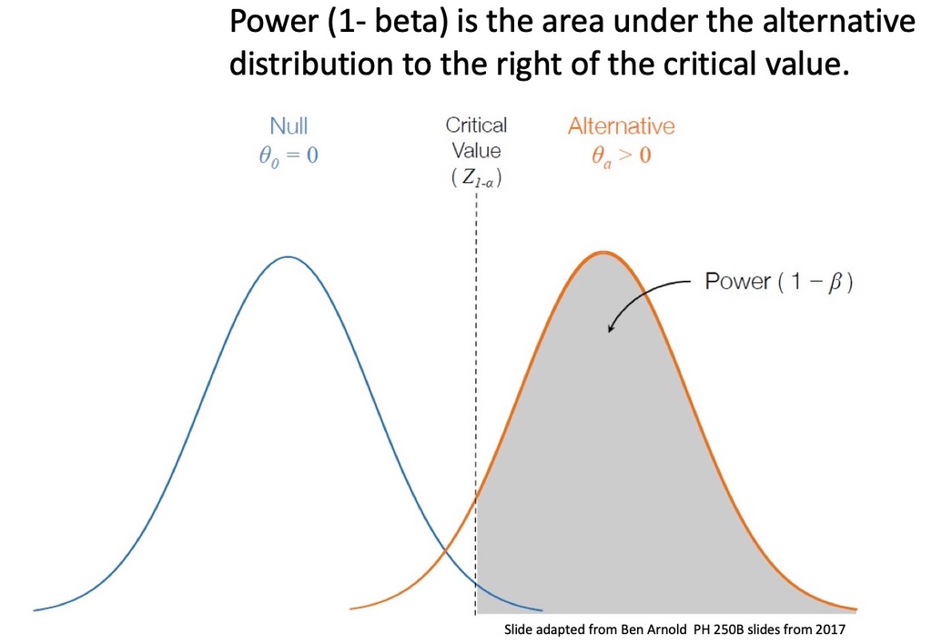

### Power

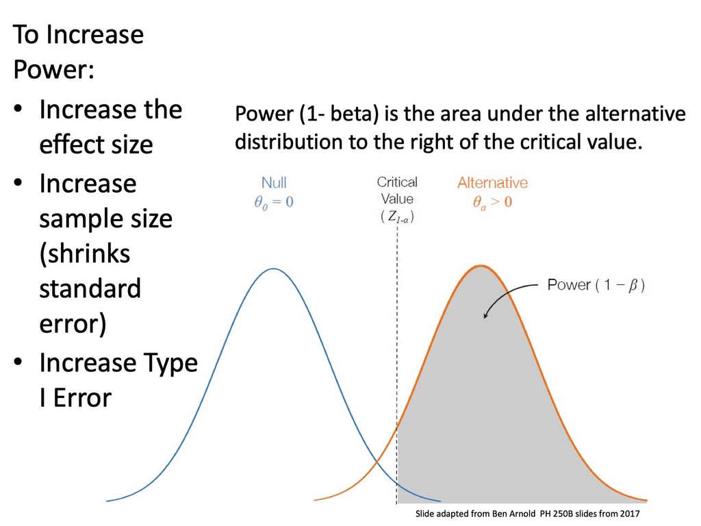

### Take Home Questions

- What is a parameter? What is a statistic?
- If P(B)=3% and P(A)=4% and are independent of one another, what is \( P(A \cap B) \)? Hint: can you multiply two percentages?
- If you're asked for the P(+), does this include both true and false positives?

### Extra

Supplementary material available [here](https://palautatan.github.io/ph142/).